# Explore gapminder

sukey

September 20, 2018

## Smell test the data

Explore the gapminder object:

```r
library(gapminder)
library(tidyverse)
library(dplyr)
```

#### Is it a data.frame, a matrix, a vector, a list?

```r
inherits(gapminder,"data.frame")
### or we can also use "str()"
str(gapminder)
```

[output not shown]

**Answer: The function returns “True”, so it is a data frame . Using str() gives you that information plus extra goodies (such as the levels of your factors and the first few values of each variable)**

#### What is its class?

```r
class(gapminder)
```

[output not shown]

#### How many variables/columns?

```r
ncol(gapminder)
```

[output not shown]

**Answer: The number of columns is 6 . Also we can use str() function and then count the number of columns**

#### How many rows/observations?

```r
nrow(gapminder)
```

[output not shown]

**Answer: The number of rows is 1704 .**

#### Can you get these facts about “extent” or “size” in more than one way? Can you imagine different functions being useful in different contexts?

```r
dim(gapminder) # this function can directly return the size
str(gapminder) # str() returns size and other info
nrow(gapminder) # nrow() can combine with ncol() to check the size of data
ncol(gapminder)
```

[output not shown]

**Answer: 1704 rows and 6 columns . dim() returns the dimensions of an object. rowNumber = dim(object)[1]; colNumber = dim(object)[2]**

#### What data type is each variable?

```r
str(gapminder)
```

```
## Classes 'tbl_df', 'tbl' and 'data.frame':    1704 obs. of  6 variables:
##  $ country  : Factor w/ 142 levels "Afghanistan",..: 1 1 1 1 1 1 1 1 1 1 ...
##  $ continent: Factor w/ 5 levels "Africa","Americas",..: 3 3 3 3 3 3 3 3 3 3 ...
##  $ year     : int  1952 1957 1962 1967 1972 1977 1982 1987 1992 1997 ...
##  $ lifeExp  : num  28.8 30.3 32 34 36.1 ...
##  $ pop      : int  8425333 9240934 10267083 11537966 13079460 14880372 12881816 13867957 16317921 22227415 ...
##  $ gdpPercap: num  779 821 853 836 740 ...
```

**Answer: The type of each variable is shown as above :**

- Country is factor
- continent is also factor
- year is int
- lifeExp is numberic
- pop is int

## Explore various plot types

```r
### There is a lot of data, but I only want to foucs on the information from Asia

info_Asia <- gapminder %>%
  filter(continent == 'Asia')
```

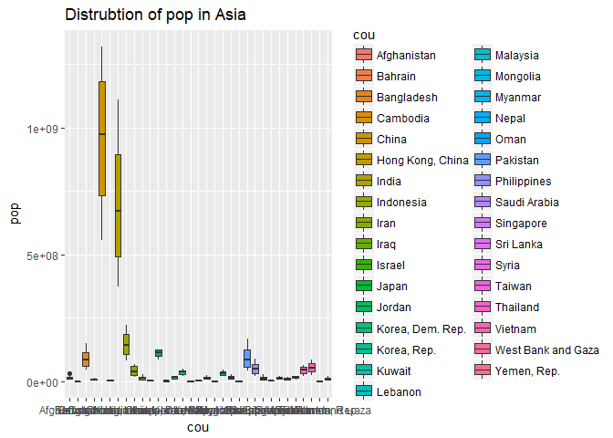

```r
summary(info_Asia$country)
info_Asia <-rename(info_Asia, cou = country)
ggplot(info_Asia, aes(cou, pop)) +
  geom_boxplot(aes(fill = cou)) +
  ggtitle("Distrubtion of pop in Asia")
```

*There are too many countries in my graph, but I only have intrest in country with huge population*

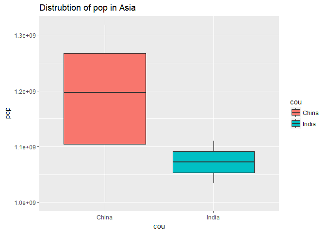

```r
info_Asia <- gapminder %>%
  filter(continent == 'Asia' & pop > 1000000000)
summary(info_Asia$country)
info_Asia <-rename(info_Asia, cou = country)
ggplot(info_Asia, aes(cou, pop)) +
  geom_boxplot(aes(fill = cou)) +
  ggtitle("Distrubtion of pop in Asia")
```

**According to the garph above, we can find that China and India are the countries with large population in Asia**

*Now I want to get more information of China and India, and find some differences*

```r
China_India <- gapminder %>%
  filter(country %in% c("China","India"))
dim(China_India)  ## check the size of China_India
```

```
## [1] 24  6
```

```r
knitr::kable(China_India) ## use table presentation
```

| country | continent | year | lifeExp | pop | gdpPercap |
| --- | --- | --- | --- | --- | --- |
| China | Asia | 1952 | 44.00000 | 556263527 | 400.4486 |
| China | Asia | 1957 | 50.54896 | 637408000 | 575.9870 |
| China | Asia | 1962 | 44.50136 | 665770000 | 487.6740 |
| China | Asia | 1967 | 58.38112 | 754550000 | 612.7057 |
| China | Asia | 1972 | 63.11888 | 862030000 | 676.9001 |
| China | Asia | 1977 | 63.96736 | 943455000 | 741.2375 |
| China | Asia | 1982 | 65.52500 | 1000281000 | 962.4214 |
| China | Asia | 1987 | 67.27400 | 1084035000 | 1378.9040 |
| China | Asia | 1992 | 68.69000 | 1164970000 | 1655.7842 |
| China | Asia | 1997 | 70.42600 | 1230075000 | 2289.2341 |
| China | Asia | 2002 | 72.02800 | 1280400000 | 3119.2809 |
| China | Asia | 2007 | 72.96100 | 1318683096 | 4959.1149 |
| India | Asia | 1952 | 37.37300 | 372000000 | 546.5657 |
| India | Asia | 1957 | 40.24900 | 409000000 | 590.0620 |
| India | Asia | 1962 | 43.60500 | 454000000 | 658.3472 |
| India | Asia | 1967 | 47.19300 | 506000000 | 700.7706 |
| India | Asia | 1972 | 50.65100 | 567000000 | 724.0325 |
| India | Asia | 1977 | 54.20800 | 634000000 | 813.3373 |
| India | Asia | 1982 | 56.59600 | 708000000 | 855.7235 |
| India | Asia | 1987 | 58.55300 | 788000000 | 976.5127 |
| India | Asia | 1992 | 60.22300 | 872000000 | 1164.4068 |
| India | Asia | 1997 | 61.76500 | 959000000 | 1458.8174 |
| India | Asia | 2002 | 62.87900 | 1034172547 | 1746.7695 |
| India | Asia | 2007 | 64.69800 | 1110396331 | 2452.2104 |

**I would to use tabke to have a first look and it seems that there are somthing intresting among population, year and gdp. Let’s check it!**

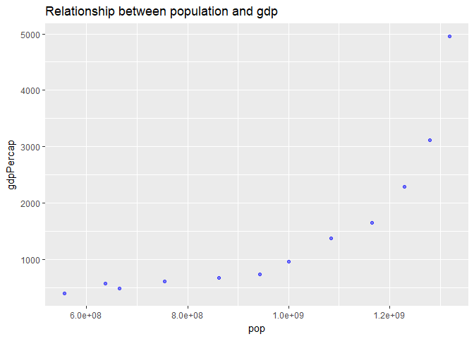

```r
#### take China as an example
China <- gapminder %>%
  filter(country == 'China') %>%
  arrange(year,pop)
#knitr::kable(China)

ggplot(China, aes(pop, gdpPercap)) +
  geom_point(alpha = 0.5,colour = "blue") +
  ggtitle("Relationship between population and gdp")
```

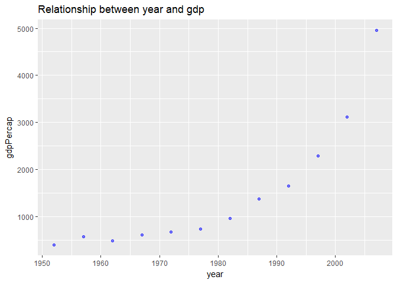

```r
ggplot(China, aes(year, gdpPercap)) +
  geom_point(alpha = 0.5,colour = "blue") +
  ggtitle("Relationship between year and gdp")
```

**As I guessed before, gdp grows up with year and population**

*if we want to see the all relationships between variables, use cool pairs()*

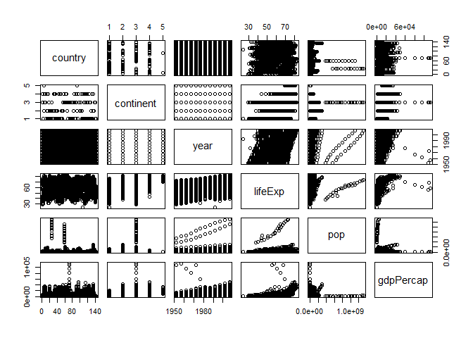

```r
pairs(gapminder)
```

*let’s try put rainbow on garph*

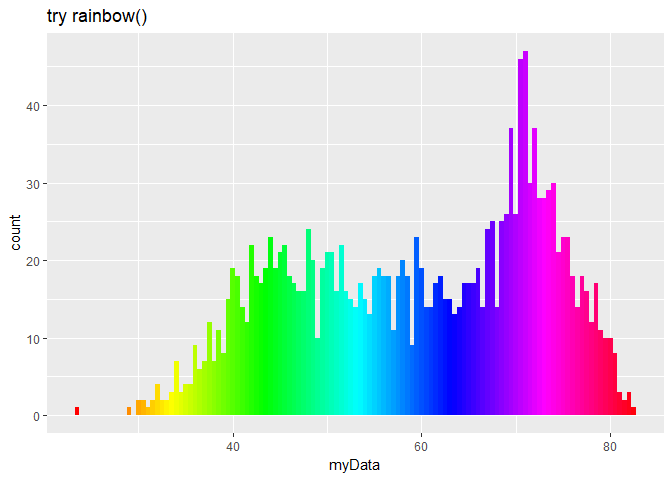

```r
myData <- gapminder %>% dplyr::select(lifeExp)
binwidth = 0.5
library(ggplot2)   # CRAN version 2.2.1 used
n_bins <- length(ggplot2:::bin_breaks_width(range(myData), width = binwidth)$breaks) - 1L
ggplot() +
  geom_histogram(aes(x = myData), binwidth = binwidth, fill = rainbow(n_bins)) +
  ggtitle("try rainbow()")
```

*one graph first and then put on another*

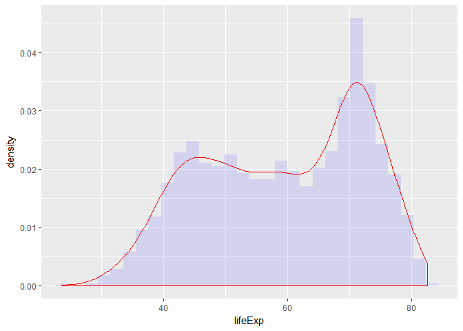

```r
ggplot(gapminder, aes(lifeExp)) +
  geom_histogram(aes(y =..density..),fill = "blue",alpha = 0.1)+
  geom_density(color = "red")
```

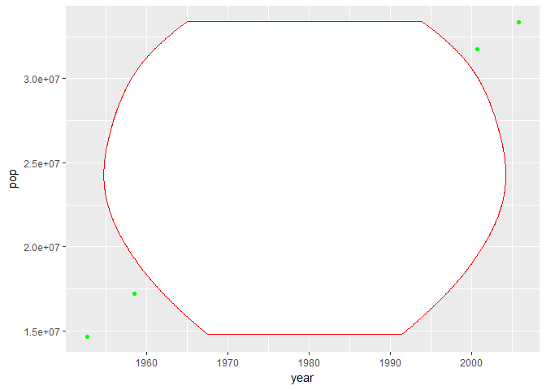

```r
gapminder %>%
  filter(country == "Canada") %>%
  ggplot(aes(year, pop)) +
  geom_jitter( colour = "green")+
  geom_violin(colour ="red")
```

## But I want to do more!

```r
afterFilter <- filter(gapminder, country == c("Rwanda", "Afghanistan"))
unique(afterFilter$country)
```

```
## [1] Afghanistan Rwanda
## 142 Levels: Afghanistan Albania Algeria Angola Argentina ... Zimbabwe
```